# Biostat 203B Homework 1

Due Jan 24, 2025 @ 11:59PM

Author

Luke Hodges 906182810

## Q1. Git/GitHub

No handwritten homework reports are accepted for this course. We work with Git and GitHub. Efficient and abundant use of Git, e.g., frequent and well-documented commits, is an important criterion for grading your homework.

Apply for the Student Developer Pack at GitHub using your UCLA email. You’ll get GitHub Pro account for free (unlimited public and private repositories).

Create a private repository biostat-203b-2025-winter and add Hua-Zhou and TA team (Tomoki-Okuno for Lec 1; parsajamshidian and BowenZhang2001 for Lec 82) as your collaborators with write permission.

Top directories of the repository should be hw1, hw2, … Maintain two branches main and develop. The develop branch will be your main playground, the place where you develop solution (code) to homework problems and write up report. The main branch will be your presentation area. Submit your homework files (Quarto file qmd, html file converted by Quarto, all code and extra data sets to reproduce results) in the main branch.

After each homework due date, course reader and instructor will check out your main branch for grading. Tag each of your homework submissions with tag names hw1, hw2, … Tagging time will be used as your submission time. That means if you tag your hw1 submission after deadline, penalty points will be deducted for late submission.

After this course, you can make this repository public and use it to demonstrate your skill sets on job market.

**Solution** Done.

## Q2. Data ethics training

This exercise (and later in this course) uses the MIMIC-IV data v3.1, a freely accessible critical care database developed by the MIT Lab for Computational Physiology. Follow the instructions at https://mimic.mit.edu/docs/gettingstarted/ to (1) complete the CITI Data or Specimens Only Research course and (2) obtain the PhysioNet credential for using the MIMIC-IV data. Display the verification links to your completion report and completion certificate here. You must complete Q2 before working on the remaining questions. (Hint: The CITI training takes a few hours and the PhysioNet credentialing takes a couple days; do not leave it to the last minute.)

**Solution** Here is the [Completion Report](https://www.citiprogram.org/verify/?ke969a4f4-b4ad-4066-bb3f-8febb17a314d-67306596) and my [Completion Certificate](https://www.citiprogram.org/verify/?w1ebe72ea-777e-4eee-8de7-0e0dd1c611a3-67306596) of my CITI Training.

## Q3. Linux Shell Commands

Make the MIMIC-IV v3.1 data available at location ~/mimic. The output of the ls -l ~/mimic command should be similar to the below (from my laptop).

content of mimic folder

```bash
#content of mimic folder
ls -l ~/mimic/
```

```
total 48
-rw-r--r--@  1 lukehodges  staff  15199 Oct 10 16:29 CHANGELOG.txt
-rw-r--r--@  1 lukehodges  staff   2518 Oct 10 17:30 LICENSE.txt
-rw-r--r--@  1 lukehodges  staff   2884 Oct 11 17:55 SHA256SUMS.txt
drwxr-xr-x@ 26 lukehodges  staff    832 Jan 20 22:00 hosp
drwxr-xr-x@ 11 lukehodges  staff    352 Jan 20 18:41 icu
lrwxr-xr-x   1 lukehodges  staff     38 Jan 20 19:35 mimic-iv-3.1 -> /Users/lukehodges/Desktop/mimic-iv-3.1
```

Refer to the documentation https://physionet.org/content/mimiciv/3.1/ for details of data files. Do not put these data files into Git; they are big. Do not copy them into your directory. Do not decompress the gz data files. These create unnecessary big files and are not big-data-friendly practices. Read from the data folder ~/mimic directly in following exercises.

Use Bash commands to answer following questions.

**Solution** I downloaded the Mimic_IV v3.1 data and it is available under the `~/mimic` folder as requested.

2. Display the contents in the folders hosp and icu using Bash command ls -l. Why are these data files distributed as .csv.gz files instead of .csv (comma separated values) files? Read the page https://mimic.mit.edu/docs/iv/ to understand what’s in each folder.

**Solution** Here is the content of the `hosp` folder

```bash
ls -l ~/mimic/hosp/
```

```
total 48249320
-rw-r--r--@ 1 lukehodges  staff     19928140 Jun 24  2024 admissions.csv.gz
-rw-r--r--@ 1 lukehodges  staff       427554 Apr 12  2024 d_hcpcs.csv.gz
-rw-r--r--@ 1 lukehodges  staff       876360 Apr 12  2024 d_icd_diagnoses.csv.gz
-rw-r--r--@ 1 lukehodges  staff       589186 Apr 12  2024 d_icd_procedures.csv.gz
-rw-r--r--@ 1 lukehodges  staff        13169 Oct  3 09:07 d_labitems.csv.gz
-rw-r--r--@ 1 lukehodges  staff     33564802 Oct  3 09:07 diagnoses_icd.csv.gz
-rw-r--r--@ 1 lukehodges  staff      9743908 Oct  3 09:07 drgcodes.csv.gz
-rw-r--r--@ 1 lukehodges  staff    811305629 Apr 12  2024 emar.csv.gz
-rw-r--r--@ 1 lukehodges  staff    748158322 Apr 12  2024 emar_detail.csv.gz
-rw-r--r--@ 1 lukehodges  staff      2162335 Apr 12  2024 hcpcsevents.csv.gz
-rw-r--r--@ 1 lukehodges  staff  18402851720 Jan 20 22:00 labevents.csv
-rw-r--r--@ 1 lukehodges  staff   2592909134 Oct  3 09:08 labevents.csv.gz
-rw-r--r--@ 1 lukehodges  staff    117644075 Oct  3 09:08 microbiologyevents.csv.gz
-rw-r--r--@ 1 lukehodges  staff     44069351 Oct  3 09:08 omr.csv.gz
-rw-r--r--@ 1 lukehodges  staff      2835586 Apr 12  2024 patients.csv.gz
-rw-r--r--@ 1 lukehodges  staff    525708076 Apr 12  2024 pharmacy.csv.gz
-rw-r--r--@ 1 lukehodges  staff    666594177 Apr 12  2024 poe.csv.gz
-rw-r--r--@ 1 lukehodges  staff     55267894 Apr 12  2024 poe_detail.csv.gz
-rw-r--r--@ 1 lukehodges  staff    606298611 Apr 12  2024 prescriptions.csv.gz
-rw-r--r--@ 1 lukehodges  staff      7777324 Apr 12  2024 procedures_icd.csv.gz
-rw-r--r--@ 1 lukehodges  staff       127330 Apr 12  2024 provider.csv.gz
-rw-r--r--@ 1 lukehodges  staff      8569241 Apr 12  2024 services.csv.gz
-rw-r--r--@ 1 lukehodges  staff     46185771 Oct  3 09:08 transfers.csv.gz
```

**Solution** Here is the content of the `icu` folder

```bash
ls -l ~/mimic/icu/
```

```
total 8506784
-rw-r--r--@ 1 lukehodges  staff       41566 Apr 12  2024 caregiver.csv.gz
-rw-r--r--@ 1 lukehodges  staff  3502392765 Apr 12  2024 chartevents.csv.gz
-rw-r--r--@ 1 lukehodges  staff       58741 Apr 12  2024 d_items.csv.gz
-rw-r--r--@ 1 lukehodges  staff    63481196 Apr 12  2024 datetimeevents.csv.gz
-rw-r--r--@ 1 lukehodges  staff     3342355 Oct  3 07:36 icustays.csv.gz
-rw-r--r--@ 1 lukehodges  staff   311642048 Apr 12  2024 ingredientevents.csv.gz
-rw-r--r--@ 1 lukehodges  staff   401088206 Apr 12  2024 inputevents.csv.gz
-rw-r--r--@ 1 lukehodges  staff    49307639 Apr 12  2024 outputevents.csv.gz
-rw-r--r--@ 1 lukehodges  staff    24096834 Apr 12  2024 procedureevents.csv.gz
```

**These data files were distrbuted as `gz` files because they are giant files and allows them to be downloaded and distributed faster and easier.**

3. Briefly describe what Bash commands zcat, zless, zmore, and zgrep do.

**Solution** Zcat decompresses a compressed file (.gz).

**Solution** Zmore views compressed files, but cannot navigate as easily

**Solution** Zless views compressed files with easy navigation line by line

**Solution** Zgrep searches compressed files for terms and returns with matching lines.

4. (Looping in Bash) What’s the output of the following bash script?

**Solution** Here is the output

```bash
for datafile in ~/mimic/hosp/{a,l,pa}*.gz
do
  ls -l $datafile
done
```

```
-rw-r--r--@ 1 lukehodges  staff  19928140 Jun 24  2024 /Users/lukehodges/mimic/hosp/admissions.csv.gz
-rw-r--r--@ 1 lukehodges  staff  2592909134 Oct  3 09:08 /Users/lukehodges/mimic/hosp/labevents.csv.gz
-rw-r--r--@ 1 lukehodges  staff  2835586 Apr 12  2024 /Users/lukehodges/mimic/hosp/patients.csv.gz
```

Display the number of lines in each data file using a similar loop. (Hint: combine linux commands zcat < and wc -l.)

**Solution** Here are the lines in admissions file

```bash
for datafile in ~/mimic/hosp/admissions.csv.gz
do
zcat < $datafile | wc -l
done
```

```
  546029
```

**Solution** Here are the lines in the labevents file

```bash
for datafile in ~/mimic/hosp/labevents.csv.gz
do
zcat < $datafile | wc -l
done
```

```
 158374765
```

**Solution** Here are the lines in the patients file

```bash
for datafile in ~/mimic/hosp/patients.csv.gz
do
zcat < $datafile | wc -l
done
```

```
  364628
```

5. Display the first few lines of admissions.csv.gz. How many rows are in this data file, excluding the header line? Each hadm_id identifies a hospitalization. How many hospitalizations are in this data file? How many unique patients (identified by subject_id) are in this data file? Do they match the number of patients listed in the patients.csv.gz file? (Hint: combine Linux commands zcat <, head/tail, awk, sort, uniq, wc, and so on.)

**Solution** Here are the first few lines of admissions.csv.gz

```bash
for datafile in ~/mimic/hosp/admissions.csv.gz
do
zcat < $datafile | head
done
```

```
subject_id,hadm_id,admittime,dischtime,deathtime,admission_type,admit_provider_id,admission_location,discharge_location,insurance,language,marital_status,race,edregtime,edouttime,hospital_expire_flag
10000032,22595853,2180-05-06 22:23:00,2180-05-07 17:15:00,,URGENT,P49AFC,TRANSFER FROM HOSPITAL,HOME,Medicaid,English,WIDOWED,WHITE,2180-05-06 19:17:00,2180-05-06 23:30:00,0
10000032,22841357,2180-06-26 18:27:00,2180-06-27 18:49:00,,EW EMER.,P784FA,EMERGENCY ROOM,HOME,Medicaid,English,WIDOWED,WHITE,2180-06-26 15:54:00,2180-06-26 21:31:00,0
10000032,25742920,2180-08-05 23:44:00,2180-08-07 17:50:00,,EW EMER.,P19UTS,EMERGENCY ROOM,HOSPICE,Medicaid,English,WIDOWED,WHITE,2180-08-05 20:58:00,2180-08-06 01:44:00,0
10000032,29079034,2180-07-23 12:35:00,2180-07-25 17:55:00,,EW EMER.,P06OTX,EMERGENCY ROOM,HOME,Medicaid,English,WIDOWED,WHITE,2180-07-23 05:54:00,2180-07-23 14:00:00,0
10000068,25022803,2160-03-03 23:16:00,2160-03-04 06:26:00,,EU OBSERVATION,P39NWO,EMERGENCY ROOM,,,English,SINGLE,WHITE,2160-03-03 21:55:00,2160-03-04 06:26:00,0
10000084,23052089,2160-11-21 01:56:00,2160-11-25 14:52:00,,EW EMER.,P42H7G,WALK-IN/SELF REFERRAL,HOME HEALTH CARE,Medicare,English,MARRIED,WHITE,2160-11-20 20:36:00,2160-11-21 03:20:00,0
10000084,29888819,2160-12-28 05:11:00,2160-12-28 16:07:00,,EU OBSERVATION,P35NE4,PHYSICIAN REFERRAL,,Medicare,English,MARRIED,WHITE,2160-12-27 18:32:00,2160-12-28 16:07:00,0
10000108,27250926,2163-09-27 23:17:00,2163-09-28 09:04:00,,EU OBSERVATION,P40JML,EMERGENCY ROOM,,,English,SINGLE,WHITE,2163-09-27 16:18:00,2163-09-28 09:04:00,0
10000117,22927623,2181-11-15 02:05:00,2181-11-15 14:52:00,,EU OBSERVATION,P47EY8,EMERGENCY ROOM,,Medicaid,English,DIVORCED,WHITE,2181-11-14 21:51:00,2181-11-15 09:57:00,0
```

**Solution** Counting the total number of rows excluding the header

```bash
zcat < ~/mimic/hosp/admissions.csv.gz | tail -n +2 | wc -l
```

```
  546028
```

**Solution** Number of unique hospitalizations

```bash
zcat < ~/mimic/hosp/admissions.csv.gz |
tail -n +2 |
awk -F, '{print $2}' |
sort |
uniq |
wc -l
```

```
  546028
```

The number of rows is the number of unique hospitalizations.

Peek the first few lines of ‘patients.csv.gz’

```bash
zcat < ~/mimic/hosp/patients.csv.gz | head
```

```
subject_id,gender,anchor_age,anchor_year,anchor_year_group,dod
10000032,F,52,2180,2014 - 2016,2180-09-09
10000048,F,23,2126,2008 - 2010,
10000058,F,33,2168,2020 - 2022,
10000068,F,19,2160,2008 - 2010,
10000084,M,72,2160,2017 - 2019,2161-02-13
10000102,F,27,2136,2008 - 2010,
10000108,M,25,2163,2014 - 2016,
10000115,M,24,2154,2017 - 2019,
10000117,F,48,2174,2008 - 2010,
```

The number of unique patients in this file is:

```bash
zcat < ~/mimic/hosp/admissions.csv.gz |
tail -n +2 |
awk -F, '{print $1}' |
sort |
uniq |
wc -l
```

```
  223452
```

This should match the number in the patients file

```bash
zcat < ~/mimic/hosp/patients.csv.gz |
tail -n +2 |
awk -F, '{print $1}' |
sort |
uniq |
wc -l
```

```
  364627
```

The total number of unique patients in the admissions file is less.

6. What are the possible values taken by each of the variable admission_type, admission_location, insurance, and ethnicity? Also report the count for each unique value of these variables in decreasing order. (Hint: combine Linux commands zcat, head/tail, awk, uniq -c, wc, sort, and so on; skip the header line.)

**Solution** You need to first examine the admissions file.

```bash
zcat < ~/mimic/hosp/admissions.csv.gz | head
```

```
subject_id,hadm_id,admittime,dischtime,deathtime,admission_type,admit_provider_id,admission_location,discharge_location,insurance,language,marital_status,race,edregtime,edouttime,hospital_expire_flag
10000032,22595853,2180-05-06 22:23:00,2180-05-07 17:15:00,,URGENT,P49AFC,TRANSFER FROM HOSPITAL,HOME,Medicaid,English,WIDOWED,WHITE,2180-05-06 19:17:00,2180-05-06 23:30:00,0
10000032,22841357,2180-06-26 18:27:00,2180-06-27 18:49:00,,EW EMER.,P784FA,EMERGENCY ROOM,HOME,Medicaid,English,WIDOWED,WHITE,2180-06-26 15:54:00,2180-06-26 21:31:00,0
10000032,25742920,2180-08-05 23:44:00,2180-08-07 17:50:00,,EW EMER.,P19UTS,EMERGENCY ROOM,HOSPICE,Medicaid,English,WIDOWED,WHITE,2180-08-05 20:58:00,2180-08-06 01:44:00,0
10000032,29079034,2180-07-23 12:35:00,2180-07-25 17:55:00,,EW EMER.,P06OTX,EMERGENCY ROOM,HOME,Medicaid,English,WIDOWED,WHITE,2180-07-23 05:54:00,2180-07-23 14:00:00,0
10000068,25022803,2160-03-03 23:16:00,2160-03-04 06:26:00,,EU OBSERVATION,P39NWO,EMERGENCY ROOM,,,English,SINGLE,WHITE,2160-03-03 21:55:00,2160-03-04 06:26:00,0
10000084,23052089,2160-11-21 01:56:00,2160-11-25 14:52:00,,EW EMER.,P42H7G,WALK-IN/SELF REFERRAL,HOME HEALTH CARE,Medicare,English,MARRIED,WHITE,2160-11-20 20:36:00,2160-11-21 03:20:00,0
10000084,29888819,2160-12-28 05:11:00,2160-12-28 16:07:00,,EU OBSERVATION,P35NE4,PHYSICIAN REFERRAL,,Medicare,English,MARRIED,WHITE,2160-12-27 18:32:00,2160-12-28 16:07:00,0
10000108,27250926,2163-09-27 23:17:00,2163-09-28 09:04:00,,EU OBSERVATION,P40JML,EMERGENCY ROOM,,,English,SINGLE,WHITE,2163-09-27 16:18:00,2163-09-28 09:04:00,0
10000117,22927623,2181-11-15 02:05:00,2181-11-15 14:52:00,,EU OBSERVATION,P47EY8,EMERGENCY ROOM,,Medicaid,English,DIVORCED,WHITE,2181-11-14 21:51:00,2181-11-15 09:57:00,0
```

Admission type is the sixth column so the possible values include:

```bash
zcat < ~/mimic/hosp/admissions.csv.gz |
tail -n +2 |
awk -F, '{print $6}' |
sort |
uniq |
wc -l
```

```
       9
```

So there are nine different admission types.

For Admissions location:

```bash
zcat < ~/mimic/hosp/admissions.csv.gz |
tail -n +2 |
awk -F, '{print $8}' |
sort |
uniq |
wc -l
```

```
      12
```

There are twelve different admission locations.

For insurance:

```bash
zcat < ~/mimic/hosp/admissions.csv.gz |
tail -n +2 |
awk -F, '{print $10}' |
sort |
uniq |
wc -l
```

```
       6
```

There are six insurance

For ethnicity:

```bash
zcat < ~/mimic/hosp/admissions.csv.gz |
tail -n +2 |
awk -F, '{print $13}' |
sort |
uniq |
wc -l
```

```
      33
```

There are 33 ethnicities.

7. The icusays.csv.gz file contains all the ICU stays during the study period. How many ICU stays, identified by stay_id, are in this data file? How many unique patients, identified by subject_id, are in this data file?

**Solution**

To start, we must look into the icusays.csv.gz file

```bash
zcat < ~/mimic/icu/icustays.csv.gz | head
```

```
subject_id,hadm_id,stay_id,first_careunit,last_careunit,intime,outtime,los
10000032,29079034,39553978,Medical Intensive Care Unit (MICU),Medical Intensive Care Unit (MICU),2180-07-23 14:00:00,2180-07-23 23:50:47,0.4102662037037037
10000690,25860671,37081114,Medical Intensive Care Unit (MICU),Medical Intensive Care Unit (MICU),2150-11-02 19:37:00,2150-11-06 17:03:17,3.8932523148148146
10000980,26913865,39765666,Medical Intensive Care Unit (MICU),Medical Intensive Care Unit (MICU),2189-06-27 08:42:00,2189-06-27 20:38:27,0.4975347222222222
10001217,24597018,37067082,Surgical Intensive Care Unit (SICU),Surgical Intensive Care Unit (SICU),2157-11-20 19:18:02,2157-11-21 22:08:00,1.1180324074074075
10001217,27703517,34592300,Surgical Intensive Care Unit (SICU),Surgical Intensive Care Unit (SICU),2157-12-19 15:42:24,2157-12-20 14:27:41,0.948113425925926
10001725,25563031,31205490,Medical/Surgical Intensive Care Unit (MICU/SICU),Medical/Surgical Intensive Care Unit (MICU/SICU),2110-04-11 15:52:22,2110-04-12 23:59:56,1.338587962962963
10001843,26133978,39698942,Medical/Surgical Intensive Care Unit (MICU/SICU),Medical/Surgical Intensive Care Unit (MICU/SICU),2134-12-05 18:50:03,2134-12-06 14:38:26,0.8252662037037037
10001884,26184834,37510196,Medical Intensive Care Unit (MICU),Medical Intensive Care Unit (MICU),2131-01-11 04:20:05,2131-01-20 08:27:30,9.17181712962963
10002013,23581541,39060235,Cardiac Vascular Intensive Care Unit (CVICU),Cardiac Vascular Intensive Care Unit (CVICU),2160-05-18 10:00:53,2160-05-19 17:33:33,1.314351851851852
```

The number of ICU stays identified by stay_id

```bash
zcat < ~/mimic/icu/icustays.csv.gz |
tail -n +2 |
awk -F, '{print $3}' |
sort |
uniq |
wc -l
```

```
   94458
```

There are 94458 ICU stays identified by the stay_id

```bash
zcat < ~/mimic/hosp/admissions.csv.gz |
tail -n +2 |
awk -F, '{print $1}' |
sort |
uniq |
wc -l
```

```
  223452
```

8. To compress, or not to compress. That’s the question. Let’s focus on the big data file labevents.csv.gz. Compare compressed gz file size to the uncompressed file size. Compare the run times of zcat < ~/mimic/labevents.csv.gz | wc -l versus wc -l labevents.csv. Discuss the trade off between storage and speed for big data files. (Hint: gzip -dk < FILENAME.gz > ./FILENAME. Remember to delete the large labevents.csv file after the exercise.)

Checking file size for the compressed version

```bash
ls -lh ~/mimic/hosp/labevents.csv.gz
```

```
-rw-r--r--@ 1 lukehodges  staff   2.4G Oct  3 09:08 /Users/lukehodges/mimic/hosp/labevents.csv.gz
```

This file is 2.4G

Checking file size for the uncompressed version

```bash
ls -lh ~/mimic/hosp/labevents.csv
```

```
-rw-r--r--@ 1 lukehodges  staff    17G Jan 20 22:00 /Users/lukehodges/mimic/hosp/labevents.csv
```

This file is 17G

Comparing the run times of the compressed and uncompressed

For Compressed

```bash
time zcat < ~/mimic/hosp/labevents.csv.gz | wc -l
```

```
 158374765

real    0m52.352s
user    1m15.551s
sys 0m4.759s
```

For Uncompressed

```bash
time wc -l ~/mimic/hosp/labevents.csv
```

```
 158374765 /Users/lukehodges/mimic/hosp/labevents.csv

real    0m56.045s
user    0m50.524s
sys 0m5.011s
```

## Q4. Who’s popular in Price and Prejudice

1. You and your friend just have finished reading Pride and Prejudice by Jane Austen. Among the four main characters in the book, Elizabeth, Jane, Lydia, and Darcy, your friend thinks that Darcy was the most mentioned. You, however, are certain it was Elizabeth. Obtain the full text of the novel from http://www.gutenberg.org/cache/epub/42671/pg42671.txt and save to your local folder.

```bash
wget -nc http://www.gutenberg.org/cache/epub/42671/pg42671.txt
for char in Elizabeth Jane Lydia Darcy
do
  echo $char:
  grep -n "$char" pg42671.txt | wc -l
done
```

```
File ‘pg42671.txt’ already there; not retrieving.

Elizabeth:
     633
Jane:
     289
Lydia:
     166
Darcy:
     414
```

Explain what wget -nc does. Do not put this text file pg42671.txt in Git. Complete the following loop to tabulate the number of times each of the four characters is mentioned using Linux commands.

Wget -nc downloads the file, but doers not replicate if it already is downloaded.

2. What’s the difference between the following two commands?

```bash
echo 'hello, world' > test1.txt
```

and

```bash
echo 'hello, world' >> test2.txt
```

The first command directs the output to the test1.txt, saying ‘hello, world’.

The second command appends (adds it) to a file named test2.txt.

Using your favorite text editor (e.g., vi), type the following and save the file as middle.sh:

#!/bin/sh # Select lines from the middle of a file. # Usage: bash middle.sh filename end_line num_lines head -n “$2” “$1” | tail -n “$3”

Using chmod to make the file executable by the owner, and run

The middle.sh is set to my desktop. The command chmod 751 gives executive function and access to the user.

```bash
chmod 751 ~/middle.sh
```

```bash
~/middle.sh pg42671.txt 20 5
```

```
Release date: May 9, 2013 [eBook #42671]

Language: English
```

Explain the output. Explain the meaning of “$1”, “$2”, and “$3” in this shell script. Why do we need the first line of the shell script?

## Q5. More fun with Linux

Try following commands in Bash and interpret the results: cal, cal 2025, cal 9 1752 (anything unusual?), date, hostname, arch, uname -a, uptime, who am i, who, w, id, last | head, echo {con,pre}{sent,fer}{s,ed}, time sleep 5, history | tail.

```bash
cal
```

```
    January 2025
Su Mo Tu We Th Fr Sa
          1  2  3  4
 5  6  7  8  9 10 11
12 13 14 15 16 17 18
19 20 21 22 23 24 25
26 27 28 29 30 31
```

**This makes a calendar of the current month of the current year**

```bash
cal 2025
```

```
                            2025
      January               February               March
Su Mo Tu We Th Fr Sa  Su Mo Tu We Th Fr Sa  Su Mo Tu We Th Fr Sa
          1  2  3  4                     1                     1
 5  6  7  8  9 10 11   2  3  4  5  6  7  8   2  3  4  5  6  7  8
12 13 14 15 16 17 18   9 10 11 12 13 14 15   9 10 11 12 13 14 15
19 20 21 22 23 24 25  16 17 18 19 20 21 22  16 17 18 19 20 21 22
26 27 28 29 30 31     23 24 25 26 27 28     23 24 25 26 27 28 29
                                            30 31

       April                  May                   June
Su Mo Tu We Th Fr Sa  Su Mo Tu We Th Fr Sa  Su Mo Tu We Th Fr Sa
       1  2  3  4  5               1  2  3   1  2  3  4  5  6  7
 6  7  8  9 10 11 12   4  5  6  7  8  9 10   8  9 10 11 12 13 14
13 14 15 16 17 18 19  11 12 13 14 15 16 17  15 16 17 18 19 20 21
20 21 22 23 24 25 26  18 19 20 21 22 23 24  22 23 24 25 26 27 28
27 28 29 30           25 26 27 28 29 30 31  29 30


        July                 August              September
Su Mo Tu We Th Fr Sa  Su Mo Tu We Th Fr Sa  Su Mo Tu We Th Fr Sa
       1  2  3  4  5                  1  2      1  2  3  4  5  6
 6  7  8  9 10 11 12   3  4  5  6  7  8  9   7  8  9 10 11 12 13
13 14 15 16 17 18 19  10 11 12 13 14 15 16  14 15 16 17 18 19 20
20 21 22 23 24 25 26  17 18 19 20 21 22 23  21 22 23 24 25 26 27
27 28 29 30 31        24 25 26 27 28 29 30  28 29 30
                      31

      October               November              December
Su Mo Tu We Th Fr Sa  Su Mo Tu We Th Fr Sa  Su Mo Tu We Th Fr Sa
          1  2  3  4                     1      1  2  3  4  5  6
 5  6  7  8  9 10 11   2  3  4  5  6  7  8   7  8  9 10 11 12 13
12 13 14 15 16 17 18   9 10 11 12 13 14 15  14 15 16 17 18 19 20
19 20 21 22 23 24 25  16 17 18 19 20 21 22  21 22 23 24 25 26 27
26 27 28 29 30 31     23 24 25 26 27 28 29  28 29 30 31
                      30
```

**This makes an annual calendar**

```bash
cal 9 1752
```

```
   September 1752
Su Mo Tu We Th Fr Sa
       1  2 14 15 16
17 18 19 20 21 22 23
24 25 26 27 28 29 30
```

**This makes a calendar for September, 1752. It skips 3-13.**

```bash
date
```

```
Fri Jan 24 11:58:49 PST 2025
```

**Gives you current date and time**

```bash
hostname
```

```
dhcp-10-144-183-115.dgsom.guest
```

**Gives name of local computer**

```bash
arch
```

```
i386
```

```bash
uname -a
```

```
Darwin dhcp-10-144-183-115.dgsom.guest 24.0.0 Darwin Kernel Version 24.0.0: Mon Aug 12 20:54:30 PDT 2024; root:xnu-11215.1.10~2/RELEASE_X86_64 x86_64
```

**Gives you more details of the local computer system, like version.**

```bash
uptime
```

```
11:58  up 4 days, 19:09, 1 user, load averages: 2.20 2.88 3.27
```

**Shows you how long the computer has been running**

```bash
who am i
```

```
lukehodges                    Jan 24 11:58
```

**Gives you name of the user with date and time**

```bash
who
```

```
lukehodges       console      Jan 19 16:49
```

**Gives you who is currently using the local computer.**

```bash
w
```

```
11:58  up 4 days, 19:09, 1 user, load averages: 2.20 2.88 3.27
USER       TTY      FROM    LOGIN@  IDLE WHAT
lukehodges console  -      Sun16   4days -
```

**Seems to summarize and add from the information above.**

```bash
id
```

```
uid=501(lukehodges) gid=20(staff) groups=20(staff),12(everyone),61(localaccounts),79(_appserverusr),80(admin),81(_appserveradm),98(_lpadmin),701(com.apple.sharepoint.group.1),33(_appstore),100(_lpoperator),204(_developer),250(_analyticsusers),395(com.apple.access_ftp),398(com.apple.access_screenshar…
```

**Displays individual and group IDs**

```bash
last | head
```

```
lukehodges ttys000                         Fri Jan 24 11:12 - 11:12  (00:00)
lukehodges ttys000                         Thu Jan 23 17:58 - 17:58  (00:00)
lukehodges ttys000                         Tue Jan 21 12:26 - 12:26  (00:00)
lukehodges ttys000                         Tue Jan 21 12:23 - 12:23  (00:00)
lukehodges ttys001                         Mon Jan 20 22:34 - 22:34  (00:00)
lukehodges ttys001                         Mon Jan 20 19:33 - 19:33  (00:00)
lukehodges ttys001                         Mon Jan 20 18:46 - 18:46  (00:00)
lukehodges ttys001                         Mon Jan 20 18:45 - 18:45  (00:00)
lukehodges ttys000                         Mon Jan 20 18:44 - 18:44  (00:00)
lukehodges ttys001                         Mon Jan 20 18:42 - 18:42  (00:00)
```

**Displays the first few lines of people who have logged in and when**

```bash
echo {con,pre}{sent,fer}{s,ed}
```

```
consents consented confers confered presents presented prefers prefered
```

**Matches every possible combination in the set in order**

```bash
time sleep 5
```

```
real    0m5.011s
user    0m0.003s
sys 0m0.005s
```

**Shows how long the sleep command takes to run**

```bash
history | tail
```

[output not shown]

**Displays the last several commands executed**

## Q6. Git clone the repository https://github.com/christophergandrud/Rep-Res-Book for the book Reproducible Research with R and RStudio to your local machine. Do not put this repository within your homework repository biostat-203b-2025-winter.

Open the project by clicking rep-res-3rd-edition.Rproj and compile the book by clicking Build Book in the Build panel of RStudio. (Hint: I was able to build git_book and epub_book directly. For pdf_book, I needed to add a line to the file Rep-Res-Book/rep-res-3rd-edition/latex/preabmle.tex.)

The point of this exercise is (1) to obtain the book for free and (2) to see an example how a complicated project such as a book can be organized in a reproducible way. Use sudo apt install PKGNAME to install required Ubuntu packages and tlmgr install PKGNAME to install missing TexLive packages.

For grading purpose, include a screenshot of Section 4.1.5 of the book here.

**Solution** Here is the picture

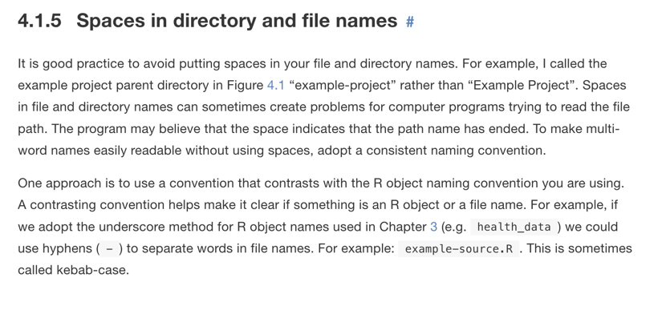